# CSCI E-63C Week 10 Problem Set

Ethan Mallove

Nov 7, 2019

# Preface

> For this week problem set we will use WiFi localization data (the one we worked with on week 2) to fit logistic regression model and evaluate performance of LDA, QDA and KNN classifiers. As we have seen earlier this dataset should allow to locate phones fairly well by relying on the strength of WiFi signal, so we should expect to see fairly low error rates for our classifiers. Let’s see whether some of those classifiers perform better than others on this data.

> **Important note:** *For the purposes of all problems in this week problem set, we will be predicting whether the phone is at location=3 or not, as opposed to working with multi-class predictor. In other words, before you proceed with any of the problems in this assignment, please convert the four-levels outcome to the outcome with only two levels: location=3 (must be 500 of those) and not (must be 1500 of them).*

> *If you are creating a new column containing this binary outcome, please make sure that the original outcome with four columns is NOT used inadvertently as one of the predictors. If you are getting invariably 100% accuracy regardless of the choice of the method or split of the data into training and test, chances are your code is using original four-levels outcome as a predictor.*

```r
library(MASS)
# An extra boolean column has been added to mark location=3 true or false (0, 1)
wifiData = matrix(scan("wifi_localization.txt"), ncol = 9, byrow = TRUE)

# Plot to pdf, so we can zoom in SVG
pdf("wifidata-pairs.pdf")
pairs(wifiData)

# Go back to default graphics device
dev.off()
```

# Problem 1 (10 points): logistic regression

> Fit logistic regression model of the binary categorical outcome (location=3 or not) using seven WiFi signals strengths as predictors in the model. Produce summary of the model, describe which attributes appear to be significantly associated with the categorical outcome in this model. Use this model to make predictions on the entire dataset and compare these predictions and corresponding true values of the class attribute using confusion matrix (i.e. contingency table). Calculate error rate (would this be training or test error in this case?), sensitivity and specificity (assuming that we are predicting class “location=3”). Describe the results.

```r
glmFit <- glm(V9~.,data=as.data.frame(wifiData),family=binomial)
summary(glmFit)
```

```
##
## Call:
## glm(formula = V9 ~ ., family = binomial, data = as.data.frame(wifiData))
##
## Deviance Residuals:
##      Min        1Q    Median        3Q       Max
## -2.79406  -0.58711  -0.22311   0.02653   2.56385
##
## Coefficients:
##              Estimate Std. Error z value Pr(>|z|)
## (Intercept) -23.61917    2.16531 -10.908  < 2e-16 ***
## V1            0.04490    0.01534   2.928  0.00342 **
## V2            0.13652    0.02027   6.735 1.64e-11 ***
## V3            0.11551    0.01809   6.386 1.71e-10 ***
## V4            0.01371    0.01487   0.922  0.35657
## V5           -0.32999    0.01880 -17.557  < 2e-16 ***
## V6           -0.06957    0.01783  -3.903 9.52e-05 ***
## V7           -0.06917    0.01592  -4.346 1.39e-05 ***
## V8            2.68274    0.18369  14.605  < 2e-16 ***
## ---
## Signif. codes:  0 '***' 0.001 '**' 0.01 '*' 0.05 '.' 0.1 ' ' 1
##
## (Dispersion parameter for binomial family taken to be 1)
##
##     Null deviance: 2249.3  on 1999  degrees of freedom
## Residual deviance: 1463.4  on 1991  degrees of freedom
## AIC: 1481.4
##
## Number of Fisher Scoring iterations: 6
```

```r
# p<0.05 in randomized data:
# pTmp <- NULL
# for ( iSim in 1:1000 ) {
#   wTmp <- wifiData
#   wTmp[,9] <- sample(wTmp[,9])
#   glmSim <- glm(V9~.,data=as.data.frame(wTmp),family=binomial)
#   pTmp <- rbind(pTmp,summary(glmSim)$coefficients[-1,"Pr(>|z|)"])
# }
# dim(pTmp)
# sum(pTmp<0.05)/prod(dim(pTmp))
# sum(apply(pTmp,1,min)<0.05)/nrow(pTmp)
# sum(pTmp<0.03)/prod(dim(pTmp))
# sum(apply(pTmp,1,min)<0.03)/nrow(pTmp)
```

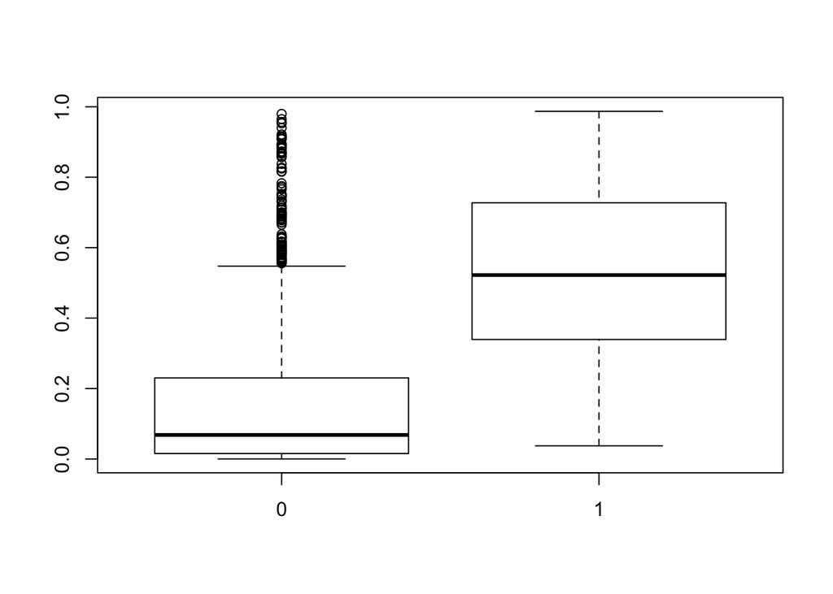

```r
boxplot(predict(glmFit,type="response")~wifiData[,9])
```

```r
quantile(predict(glmFit,type="response"))
```

```
##           0%          25%          50%          75%         100%
## 0.0001669344 0.0246016557 0.1475439043 0.4169786314 0.9871348774
```

```r
table(wifiData[,9],c("loc 3","loc not 3")[1+(predict(glmFit)>0.0)])
```

```
##
##     loc 3 loc not 3
##   0  1370       130
##   1   239       261
```

```r
tblTmp <- table(wifiData[,9],c("loc 3","loc not 3")[1+(predict(glmFit,type="response")>0.5)])
tblTmp
```

```
##
##     loc 3 loc not 3
##   0  1370       130
##   1   239       261
```

```r
# sensitivity for predicting "loc 3":
tblTmp[2,2] / sum(tblTmp[2,])
```

```
## [1] 0.522
```

```r
# specificity for predicting "loc not 3":
tblTmp[1,1] / sum(tblTmp[1,])
```

```
## [1] 0.9133333
```

```r
rocDatTmp <- NULL

for ( qTmp in quantile(predict(glmFit,type="response"),(0:10)/10) ) {
  tblTmp <- table(wifiData[,9], factor(c("loc 3", "loc not 3")[1+(predict(glmFit, type="response")>=qTmp)], c("loc 3", "loc not 3")))
  cat(qTmp,tblTmp[2,2] / sum(tblTmp[2,]),tblTmp[1,1] / sum(tblTmp[1,]),fill=TRUE)
  rocDatTmp <- rbind(rocDatTmp,c(1-tblTmp[1,1] / sum(tblTmp[1,]),tblTmp[2,2] / sum(tblTmp[2,])))
}
```

```
## 0.0001669344 1 0
## 0.005563195 1 0.1333333
## 0.01725517 1 0.2666667
## 0.0392031 0.998 0.3993333
## 0.07847887 0.984 0.528
## 0.1475439 0.95 0.65
## 0.2344342 0.862 0.754
## 0.3515689 0.73 0.8433333
## 0.4896358 0.534 0.9113333
## 0.6778161 0.298 0.966
## 0.9871349 0.002 1
```

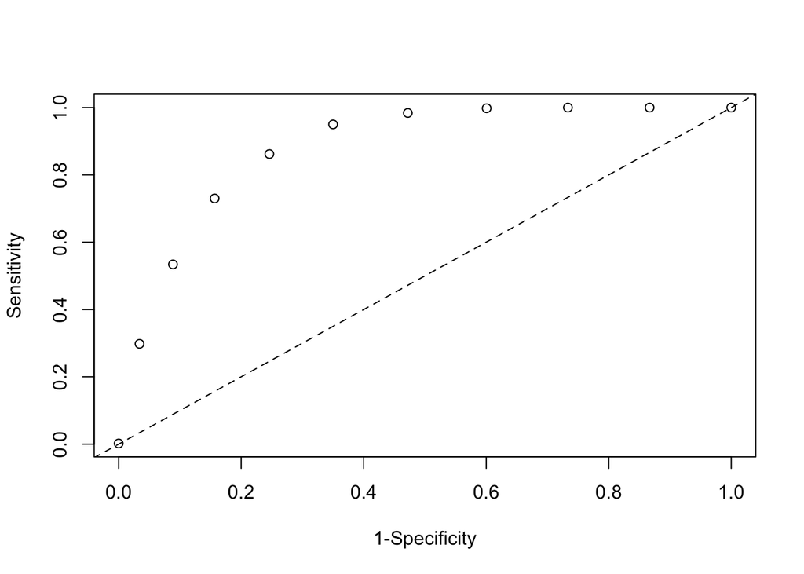

```r
plot(rocDatTmp,ylab="Sensitivity",xlab="1-Specificity")
abline(0,1,lty=2)
```

Sensitivity: 0.522 Specificity: 0.913333